# BGG Game Profiles

Phil Henrickson

2022-01-15

## What is this analysis?

This notebook is for selecting any boardgame and identifying **its most comparable games using data from boardgamegeek.com**. I use a dimension reduction method (PCA) to learn the main points of variation in data about games from boardgamegeek. To find similar games, I compute the distance between all games using their first twenty principal components. I use the distance between games to determine their overall similarity. Games that are close to each other are said to be *neighbors*.

This document details a game’s 25 nearest neighbors and illustrate some of the dimensions that make the selected game and its neighbors similar.

## Game Profile: **Tindaya**

First, we can look at summary information for the game as it currently stands on BGG. For the average rating (Average), geek rating (Geek), and average weight (Complexity) of a game, I estimate the game’s values using predictive models trained on historical BGG data.

| ID | Game | Published | Player Count | Playing Time | UserRatings | Type | Outcomes Average | Outcomes Geek | Outcomes Complexity |
| --- | --- | --- | --- | --- | --- | --- | --- | --- | --- |
| 317511 | Tindaya | 2022 | 1-4 | 120 min | 90 | Current | 8.89 | 5.57 | 3.73 |
|  |  |  |  |  |  | Estimated | 7.68 | 7.14 | 3.63 |

Information on the game’s designers, artists, mechanics and categories. Note: designer and artist features are not used in identifying nearest neighbors.

| ID | Game | Published | Publisher(s) | Designer(s) | Artist(s) | Categories | Mechanics |
| --- | --- | --- | --- | --- | --- | --- | --- |
| 317511 | Tindaya | 2022 | Red Mojo | Lolo González | Javier González Cava | Civilization | Tile Placement |
|  |  |  |  |  |  | Mythology | Modular Board |
|  |  |  |  |  |  | Environmental | Cooperative Game |
|  |  |  |  |  |  | Religious | Hexagon Grid |
|  |  |  |  |  |  |  | Area Majority Influence |
|  |  |  |  |  |  |  | Grid Movement |
|  |  |  |  |  |  |  | Traitor Game |
|  |  |  |  |  |  |  | Solo Solitaire Game |
|  |  |  |  |  |  |  | Scenario Mission Campaign Game |
|  |  |  |  |  |  |  | Turn Order Statbased |
|  |  |  |  |  |  |  | Events |
|  |  |  |  |  |  |  | End Game Bonuses |
|  |  |  |  |  |  |  | Variable Setup |
|  |  |  |  |  |  |  | Negotiation |
|  |  |  |  |  |  |  | Worker Placement Different Worker Types |
|  |  |  |  |  |  |  | Hidden Victory Points |

For the full profile of the selected game, go to https://boardgamegeek.com/boardgame/317511

## Most Similar Games to **Tindaya**

The table below displays the most similar games to Tindaya using data from boardgamegeek (BGG). The reported similarity score is the (squared) inverse of the Manhattan distance between two games.

**Note:** The analysis does not make use of a game’s number of ratings, average, or geek average, but instead looks only at a game’s categories, mechanics, playing time, player count, and complexity. The current approach for computing the distance weighs each component equally; I plan to explore a change to this in the future by using different measures of distance, as we would reasonably expect some components to be more important than others. I initially relied on Euclidean distance, but in tinkering with the results I have opted to go with the Manhattan distance for now.

| Rank | Similarity | Published | ID | Neighbor | BGGRating | GeekRating | Complexity |
| --- | --- | --- | --- | --- | --- | --- | --- |
| 1 | 14.53 | 2012 | 121921 | Robinson Crusoe: Adventures on the Cursed Island | 7.82 | 7.65 | 3.80 |
| 2 | 14.50 | 2021 | 291572 | Oath: Chronicles of Empire and Exile | 8.01 | 6.94 | 4.00 |
| 3 | 14.45 | 2019 | 286096 | Tapestry | 7.46 | 7.20 | 2.89 |
| 4 | 14.36 | 2017 | 195421 | Near and Far | 7.77 | 7.35 | 2.84 |
| 5 | 14.20 | 2015 | 156496 | March of the Ants | 7.18 | 6.17 | 2.61 |
| 6 | 14.20 | 2021 | 249277 | Brazil: Imperial | 8.40 | 5.88 | 3.05 |
| 7 | 14.17 | 2019 | 266507 | Clank!: Legacy – Acquisitions Incorporated | 8.70 | 7.85 | 2.69 |
| 8 | 14.09 | 2019 | 210296 | DinoGenics | 7.70 | 6.63 | 2.91 |
| 9 | 14.07 | 2018 | 211128 | Coma Ward | 6.09 | 5.53 | 3.17 |
| 10 | 14.03 | 2015 | 181530 | Runebound (Third Edition) | 7.49 | 6.93 | 2.69 |
| 11 | 14.02 | 2019 | 233932 | Mountaineers | 6.80 | 5.62 | 2.33 |
| 12 | 14.01 | 2021 | 331787 | Tiny Epic Dungeons | 8.16 | 5.58 | 2.27 |
| 13 | 13.98 | 2016 | 171479 | Commissioned | 7.28 | 6.06 | 2.81 |
| 14 | 13.97 | 2019 | 265402 | In the Hall of the Mountain King | 7.77 | 6.86 | 2.81 |
| 15 | 13.96 | 2015 | 150484 | Secrets of the Lost Tomb | 7.33 | 5.83 | 3.26 |
| 16 | 13.96 | 2019 | 198985 | Day Night Z | 7.61 | 5.67 | 3.68 |
| 17 | 13.94 | 2019 | 279644 | Peloponnesian War | 7.63 | 5.80 | 4.00 |
| 18 | 13.94 | 2021 | 318322 | Hidden Strike: American Revolution | 7.15 | 5.53 | 1.86 |
| 19 | 13.91 | 2012 | 122599 | Winter Tales | 5.80 | 5.56 | 2.65 |
| 20 | 13.89 | 2021 | 314393 | Wutaki | 8.06 | 5.57 | 2.73 |
| 21 | 13.87 | 2019 | 249590 | Nevsky: Teutons and Rus in Collision 1240-1242 | 8.27 | 6.05 | 3.91 |
| 22 | 13.87 | 2020 | 308765 | Praga Caput Regni | 8.10 | 7.34 | 3.72 |
| 23 | 13.86 | 2021 | 267333 | Goetia: Nine Kings of Solomon | 7.91 | 5.69 | 3.00 |
| 24 | 13.86 | 2011 | 112210 | Metro 2033 | 5.78 | 5.51 | 2.65 |
| 25 | 13.85 | 2021 | 322588 | Origins: First Builders | 7.29 | 5.76 | 3.14 |

## Plotting Comparable Games to **Tindaya**

Placing the selected game and its nearest neighbors on the first two principal components.

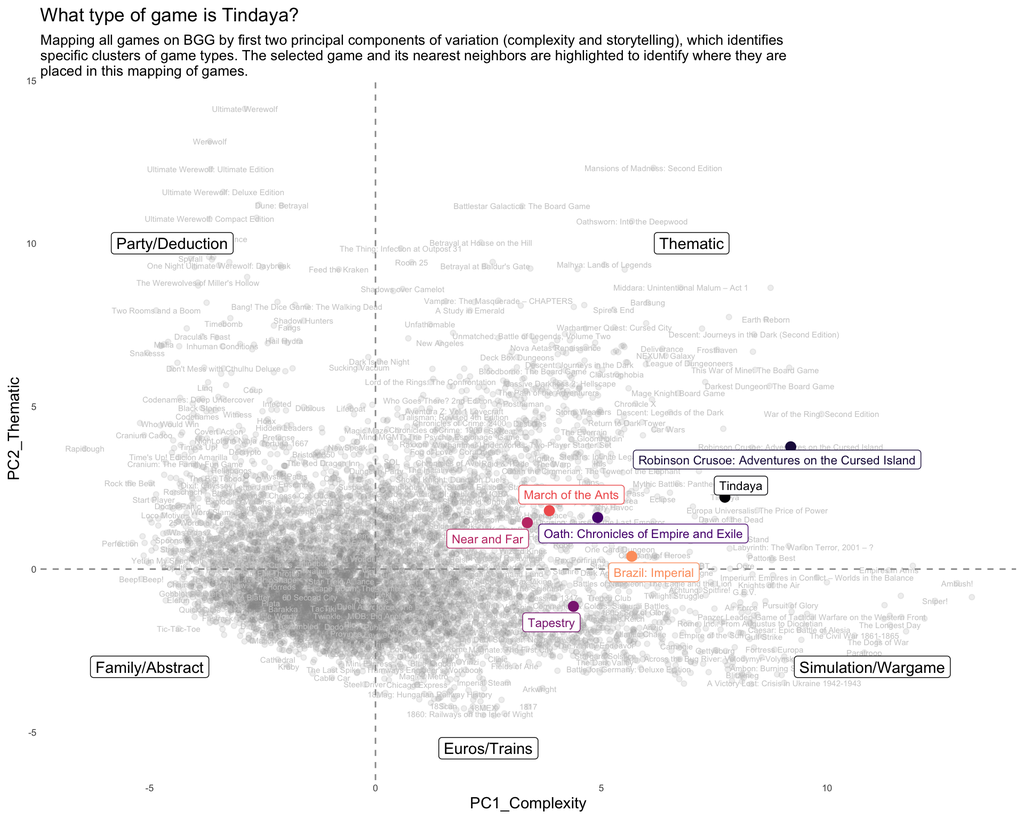

Placing games on the first four principal components, which I have found to loosely map to complexity, theme, economy, and cooperation.

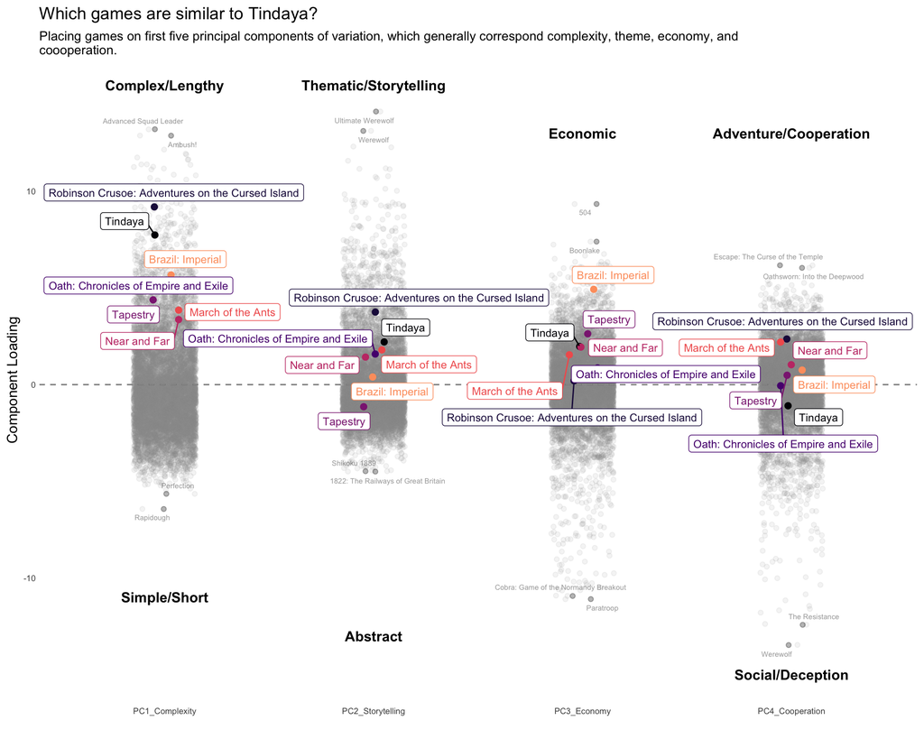

## Comparing Games on Principal Components

The chart below shows how Tindaya compares to its nearest neighbors on each of the ten principal components. Similar games will have similar profiles in terms of their placement on each dimension. This can be a useful way to easily see the dimensions on which games resemble each other. I’ve also plotted games that are at the tails of each component to get a reference point.

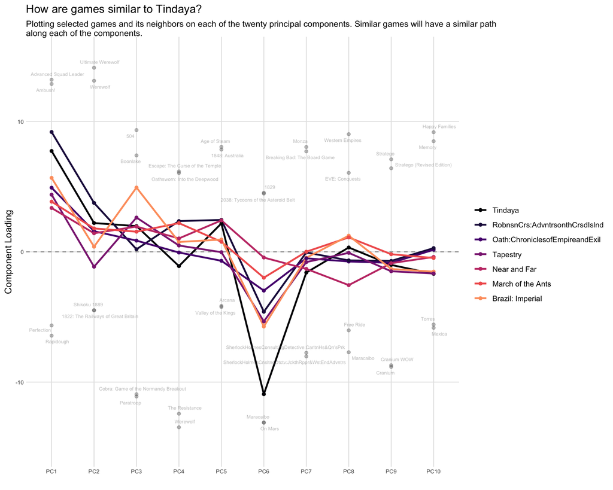

We can also use a tile plot to view each of the neighbors across every principal component used, which can be a useful way of looking to see if there’s one dimension in particular on which the games stand out.

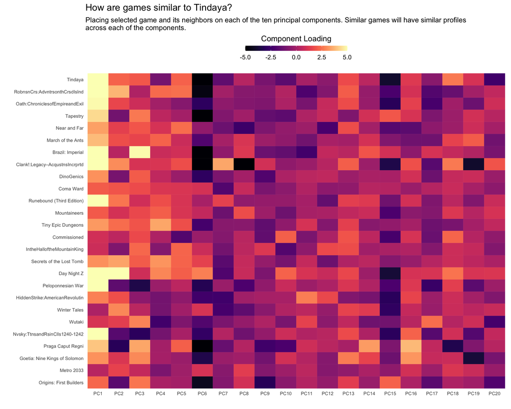